# Valoración del riesgo invasor en la Península Ibérica

Erola Fenollosa, Olga Burgos, Gianluca Arauz, Ramón Diaz

July 10, 2018

# 1 Especies invasoras - Un problema global

-Las especies invasoras suponen una problema muy importante para la biodiversidad. De hecho, se consideran la segunda mayor amenaza a la biodiversidad, después de la pérdida de hábitat. Según la ICN (GIAN -> Qué es la ICN? Primero decir qué és y luego poner las siglas), las especies invasoras son:

> “Especie exótica invasora”: especie exótica que se establece en un ecosistema o hábitat natural o seminatural; es un agente de cambio y amenaza la diversidad biológica nativa. (UICN, 2000)

## 1.1 ¿Por qué son invasoras?

Existen diversas hipótesis que tratan de explicar los motivos por los cuales algunas especies se convierten en invasoras. La hipótesis mayoritaria es que la falta de enemigos naturales en el nuevo habitat donde la invasora llega, le permite crecer sin control invirtiendo menos en compuestos y estrategias defensivas. Esta es la *Enemy Release Hypothesis*.

Otros autores postulan la regla del 10. De diez especies exóticas que llegan a un nuevo terreno, una se convierte en invasora. Esta hipótesis se basa en el azar y el hecho de que algunas comunidades son mas fáciles de ser invadidas que otras.

Una tercera corriente postula que hay ciertos rasgos que proporcionan a las especies invasoras mayores posibilidades para serlo. Por ejemplo, grandes inversiones en dispersión de semillas, ciclos de vida cortos o crecimiento clonal son algunos de los rasgos propuestos, como los que definen a un “buen invasor”.

Ninguna de estas hipótesis és excluyente, por lo que los factores determinantes del éxito invasor podría ser una combinación de aspectos de las tres corrientes. En cualquier caso, resulta evidente que un mejor conocimiento de los factores que determinan si una especie podría convertirse en invasora, sería vital para las políticas de conservación de la biodiversidad, pues la prevención es la acción más económica para erradicar una especie invasora.

Por eso nosotros queremos comprobar hasta qué punto la similitud con el marco climático de una región, en nuestro caso la Península Íbérica, puede favorecer a la invasión biológica y de esta manera deducir en qué países o regiones, debido a este solapamiento, deben implementarse medidas de prevención mayores.

# 2 Preguntas de partida y definiciones iniciales

## 2.1 Preguntas

Si las invasiones son exitosas por coincidencia del clima, ¿qué especies podrían aclimatarse en la península ibérica y son por tanto potencialmente invasoras?

¿Las especies invasoras actuales en la península ibérica cumplen esa hipótesis de coincidencia del clima? Si las condiciones climáticas en la península cambiasen en el contexto del cambio climático, ¿el número de especies potencialmente invasoras sería mayor, menor o igual? ¿El cambio climático podría potenciar la amenaza invasora?

Teniendo en cuenta el origen de las especies potencialmente invasoras y los movimientos globales de mercancías y personas, ¿qué invasiones son mas probables? ¿Con qué países deberíamos endurecer las políticas de comercio de especies?

¿Por qué superficie se extenderían las especies potencialmente invasoras en la península? ¿Cuánto es su daño potencial?

Teniendo en cuenta las condiciones climáticas en la península, ¿qué otros países de Europa podrían ser susceptibles a la invasión debido a similitudes con el marco climático de España y Portugal?

## 2.2 Definiciones

**Marco climatico Ibérico**: Espacio multidimensional definido por los valores de diferentes variables bioclimáticas georreferenciados dentro de la Península Ibérica.

**Variable bioclimática**: Variable descriptora ambiental considerada determinante para el crecimiento, desarrollo y reproducción de la biosfera.

**Nicho climático**: Espacio multidimensional definido por los valores de diferentes variables bioclimáticas de los puntos de presencia de una especie.

**Especie potencialmente invasora en la Peninsula Ibérica**: Especie cuyo nicho climático está comprendido dentro del MCI.

# 3 Paquetes necesarios

Antes de empezar, instalaremos los paquetes necesarios a lo largo del documento.

```r
new.packages <- list.of.packages[!(list.of.packages %in% installed.packages()[,"Package"])]
if(length(new.packages)) install.packages(new.packages)
```

Una vez disponibles todos los paquetes, podemos cargar las respectivas librerías.

```r
library("raster")
```

# 4 Delimitación del MCI

En primer lugar descargaremos el *dataset* de la base de datos globales [WorldClim](http://worldclim.org/). Elegiremos las [19 variables bioclimáticas](http://worldclim.org/bioclim) con una resolución geográfica de 2.5’ (minutos de grado). El argumento `var = "bio"` de la función `getData()` reclama dichas variables bioclimáticas. El portal WorldClim incluye variables climáticas teniendo en cuenta un contexto de cambio climático. Más adelante se pueden testear las diferencias. Las variables referentes a la temperatura están multiplicadas por 10.

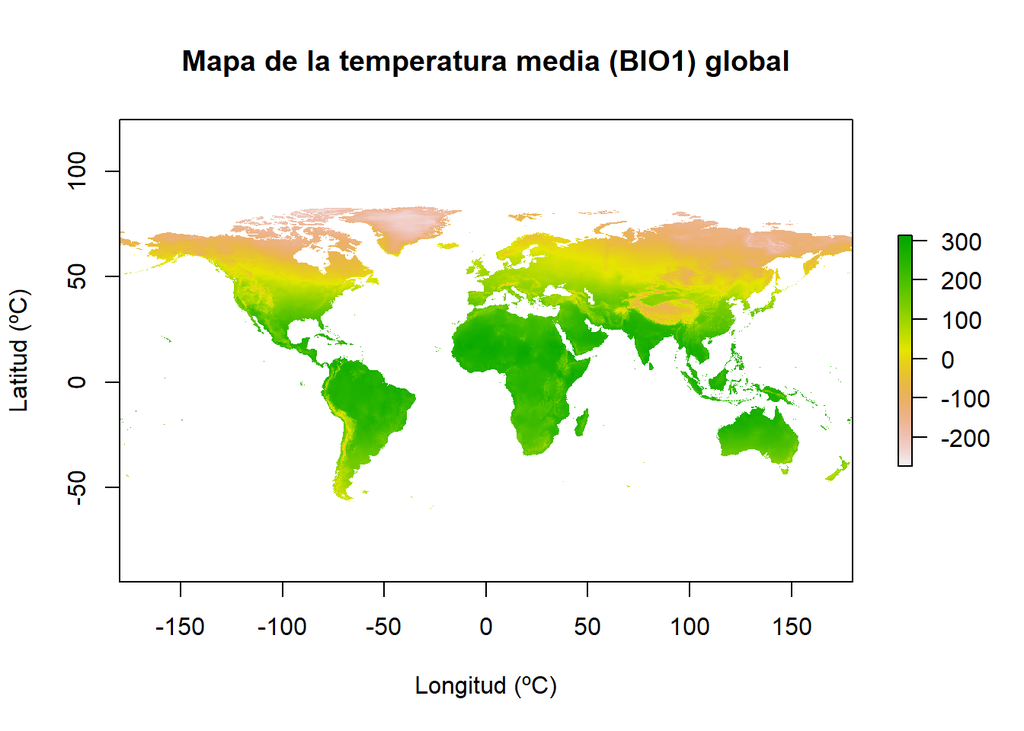

```r
worldata <- getData("worldclim",var="bio", res=2.5)

plot (worldata$bio1,
   main = "Mapa de la temperatura media (BIO1) global",
   xlab = "Longitud (ºC)",
   ylab = "Latitud (ºC)")
```

Los datos de `worldata` se encuentran en formato rasterizado. Ahora debemos seleccionar la extensión correspondiente a la Península Ibérica. Pasaremos la ventana de latitudes y longitudes que enmarcan la Península Ibérica a la función `extent()`: $(-10^\circ W, 4^\circ E)$ y $(36^\circ N, 44^\circ N)$. Seguidamente, recortaremos la extensión `e` sobre los datos `worldata` utilizando la función `crop()`.

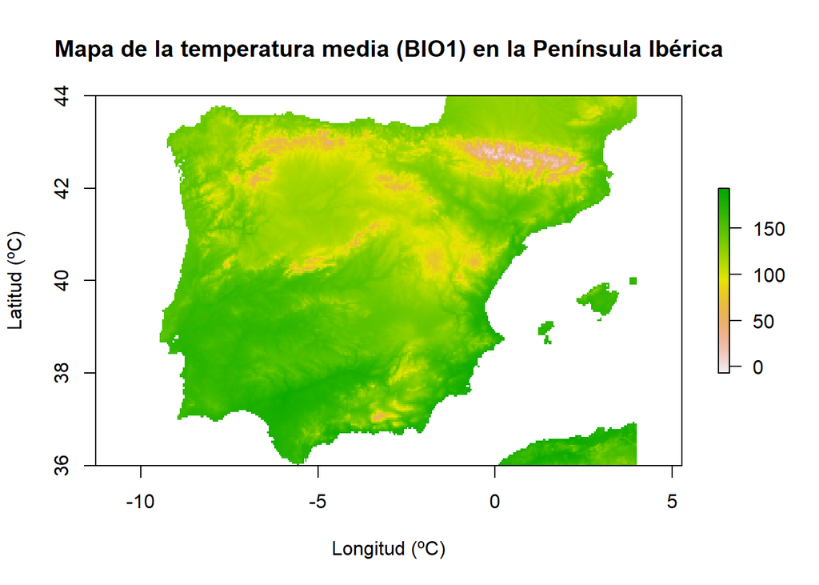

```r
e <- extent(-10, 4, 36, 44)
s.crop <- crop(worldata, e)

plot (s.crop$bio1,
   main = "Mapa de la temperatura media (BIO1) en la Península Ibérica",
   xlab = "Longitud (ºC)",
   ylab = "Latitud (ºC)")
```

El archivo `s.crop` también se encuentra en formato rasterizado. Para trabajar más cómodamente, construiremos un *dataframe* llamado `marcoclim`, definiendo los nombres de las variables bioclimáticas:

```r
#Es una matriz de 19 variables, nos faltan las coordenadas de cada punto, aunque no son esenciales.

# GIAN -> Creo que no hace falta pasar por as.matrix para obtener marcoclim. Se puede pasar directament s.crop a as.data.frame() y el resultado es el mismo.
#a<-as.matrix(s.crop)
#marcoclim <- as.data.frame(a)

marcoclim <- as.data.frame(s.crop)

BIOs <- paste('BIO', (1:19), sep = '')
names(marcoclim) <- BIOs

#summary(marcoclim)
```

Finalmente, exportamos el *dataframe* `marcoclim` en formato `*.csv`.

```r
write.csv(marcoclim, file="Datos/MarcoClim2.5.csv")
```

# 5 Análisis exploratorio

!!!!!!!!! PARA REEMPRENDER DESDE AQUí, CARGA LOS DATOS !!!!!!!!!!!

```r
marcoclim<- read_csv("Datos/MarcoClim2.5.csv",
    col_types = cols(X1 = col_skip()))
#View(marcoclim)
```

Antes de continuar trabajando, necesitamos hacernos una idea de cómo son los datos, para ello realizamos un pequeño análisis exploratorio y *data wrangling*.

```r
library(DataExplorer)
marcoclim <- marcoclim[complete.cases(marcoclim),] # Elimina NA. Los NANs son los datos correspondientes al mar?
marcoclim <- na.omit(marcoclim)
summary(marcoclim) #resumen de cada variable
```

```
##       BIO1            BIO2            BIO3            BIO4
##  Min.   : -7.0   Min.   : 52.0   Min.   :26.00   Min.   :2602
##  1st Qu.:116.0   1st Qu.: 93.0   1st Qu.:37.00   1st Qu.:5249
##  Median :134.0   Median :103.0   Median :38.00   Median :5782
##  Mean   :133.3   Mean   :101.5   Mean   :37.78   Mean   :5685
##  3rd Qu.:156.0   3rd Qu.:113.0   3rd Qu.:39.00   3rd Qu.:6264
##  Max.   :193.0   Max.   :129.0   Max.   :50.00   Max.   :7338
##       BIO5            BIO6              BIO7            BIO8
##  Min.   :113.0   Min.   :-104.00   Min.   :123.0   Min.   :-15.0
##  1st Qu.:259.0   1st Qu.:  -2.00   1st Qu.:241.0   1st Qu.: 82.0
##  Median :286.0   Median :  15.00   Median :268.0   Median :104.0
##  Mean   :284.7   Mean   :  19.02   Mean   :265.7   Mean   :104.1
##  3rd Qu.:313.0   3rd Qu.:  43.00   3rd Qu.:293.0   3rd Qu.:125.0
##  Max.   :364.0   Max.   :  91.00   Max.   :335.0   Max.   :206.0
##       BIO9           BIO10         BIO11            BIO12
##  Min.   :-26.0   Min.   : 64   Min.   :-66.00   Min.   : 219.0
##  1st Qu.:180.0   1st Qu.:189   1st Qu.: 44.00   1st Qu.: 477.0
##  Median :204.0   Median :209   Median : 62.00   Median : 592.0
##  Mean   :192.3   Mean   :209   Mean   : 64.06   Mean   : 668.9
##  3rd Qu.:232.0   3rd Qu.:234   3rd Qu.: 87.00   3rd Qu.: 796.0
##  Max.   :282.0   Max.   :284   Max.   :133.00   Max.   :1757.0
##      BIO13            BIO14            BIO15          BIO16
##  Min.   : 31.00   Min.   :  0.00   Min.   :11.0   Min.   : 84.0
##  1st Qu.: 61.00   1st Qu.:  5.00   1st Qu.:26.0   1st Qu.:162.0
##  Median : 79.00   Median : 14.00   Median :37.0   Median :216.0
##  Mean   : 87.55   Mean   : 19.87   Mean   :38.7   Mean   :238.5
##  3rd Qu.:104.00   3rd Qu.: 30.00   3rd Qu.:52.0   3rd Qu.:286.0
##  Max.   :268.00   Max.   :105.00   Max.   :78.0   Max.   :713.0
##      BIO17            BIO18            BIO19
##  Min.   :  8.00   Min.   : 15.00   Min.   : 63.0
##  1st Qu.: 36.00   1st Qu.: 39.00   1st Qu.:124.0
##  Median : 68.00   Median : 76.00   Median :189.0
##  Mean   : 83.52   Mean   : 91.52   Mean   :209.3
##  3rd Qu.:117.00   3rd Qu.:129.00   3rd Qu.:261.0
##  Max.   :340.00   Max.   :340.00   Max.   :713.0
```

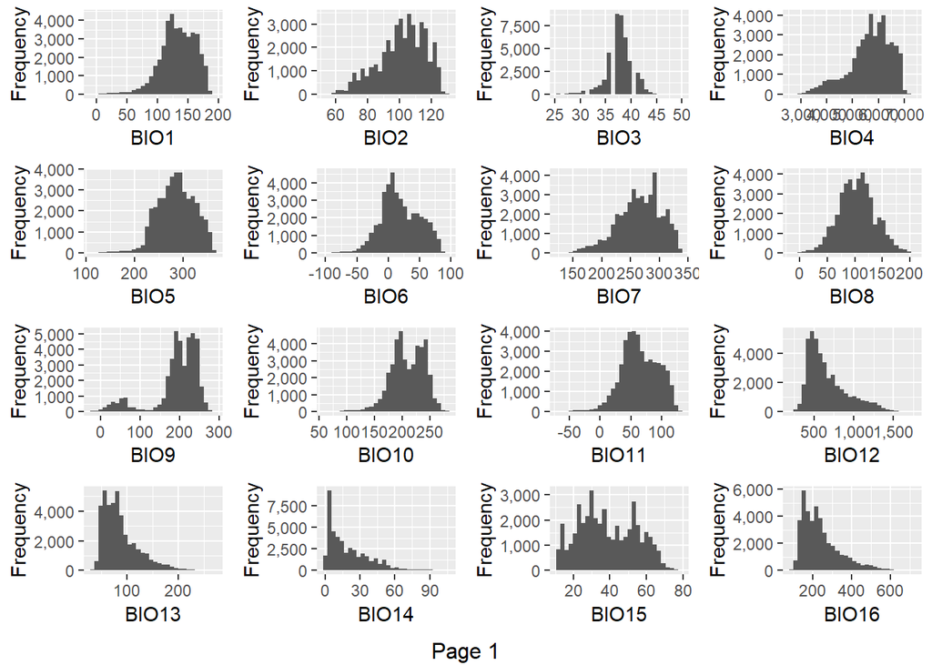

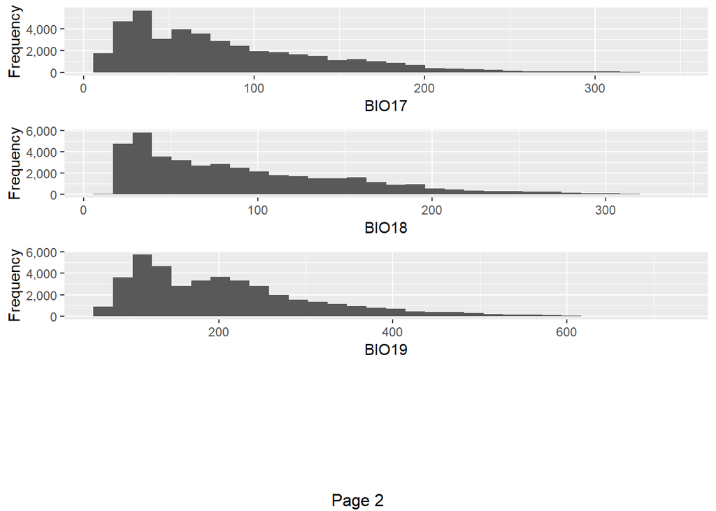

```r
plot_str(marcoclim) #estructura de los datos
plot_histogram(marcoclim)
```

```r
cor(marcoclim) # Idea de la correlación de unas variables con otras
```

```
##              BIO1        BIO2        BIO3        BIO4        BIO5
## BIO1   1.00000000  0.05745263  0.08162744 -0.02043545  0.75508336
## BIO2   0.05745263  1.00000000  0.19064491  0.75829455  0.63893689
## BIO3   0.08162744  0.19064491  1.00000000 -0.47392047 -0.06545336
## BIO4  -0.02043545  0.75829455 -0.47392047  1.00000000  0.58886073
## BIO5   0.75508336  0.63893689 -0.06545336  0.58886073  1.00000000
## BIO6   0.88991767 -0.34002661  0.18703899 -0.44730808  0.40483785
## BIO7   0.03197813  0.91415986 -0.21717464  0.95120847  0.67029277
## BIO8   0.46125076 -0.05692066 -0.09820139  0.03374289  0.26945168
## BIO9   0.65009504  0.31133700  0.15379036  0.13484322  0.67127325
## BIO10  0.92866562  0.33213028 -0.10317603  0.34923725  0.92708179
## BIO11  0.94597712 -0.19366471  0.21563532 -0.33794622  0.52372827
## BIO12 -0.36832373 -0.58103498  0.15140274 -0.61860286 -0.66076923
## BIO13 -0.13026416 -0.60494417  0.17583319 -0.66779239 -0.50026831
## BIO14 -0.76187111 -0.39146327 -0.04101834 -0.28826992 -0.83450979
## BIO15  0.74725027  0.02134753  0.10380691 -0.09398058  0.58600310
## BIO16 -0.10014978 -0.57913362  0.20526768 -0.66597417 -0.46158265
## BIO17 -0.73797558 -0.41342701 -0.02232853 -0.31934264 -0.83503058
## BIO18 -0.70075029 -0.47701265 -0.06745359 -0.34410510 -0.84281238
## BIO19 -0.01916189 -0.47594877  0.25215299 -0.60961091 -0.33630823
##              BIO6         BIO7        BIO8        BIO9      BIO10
## BIO1   0.88991767  0.031978131  0.46125076  0.65009504  0.9286656
## BIO2  -0.34002661  0.914159861 -0.05692066  0.31133700  0.3321303
## BIO3   0.18703899 -0.217174644 -0.09820139  0.15379036 -0.1031760
## BIO4  -0.44730808  0.951208465  0.03374289  0.13484322  0.3492373
## BIO5   0.40483785  0.670292768  0.26945168  0.67127325  0.9270818
## BIO6   1.00000000 -0.407204861  0.35446800  0.51387434  0.6708360
## BIO7  -0.40720486  1.000000000 -0.01853633  0.25345257  0.3815804
## BIO8   0.35446800 -0.018536334  1.00000000 -0.01616453  0.4365950
## BIO9   0.51387434  0.253452566 -0.01616453  1.00000000  0.6671937
## BIO10  0.67083602  0.381580399  0.43659502  0.66719370  1.0000000
## BIO11  0.98223176 -0.274030873  0.41686509  0.57386288  0.7634453
## BIO12 -0.02305118 -0.641301468 -0.48926664 -0.27566614 -0.5754412
## BIO13  0.21249564 -0.672149550 -0.40508643 -0.11703358 -0.3664959
## BIO14 -0.55360456 -0.384257232 -0.23480979 -0.65884470 -0.8311749
## BIO15  0.73344693 -0.009919597  0.01524921  0.58327554  0.6800147
## BIO16  0.24159150 -0.657121910 -0.44285103 -0.07918200 -0.3369280
## BIO17 -0.51779970 -0.413835831 -0.24416928 -0.61932264 -0.8207419
## BIO18 -0.47190451 -0.458856161 -0.15258199 -0.67877096 -0.7947417
## BIO19  0.29012576 -0.571380864 -0.50874354  0.06931858 -0.2400887
```

[output cut: 25 more lines]

```
## BIO5  -0.4615827 -0.83503058 -0.84281238 -0.33630823
## BIO6   0.2415915 -0.51779970 -0.47190451  0.29012576
## BIO7  -0.6571219 -0.41383583 -0.45885616 -0.57138086
## BIO8  -0.4428510 -0.24416928 -0.15258199 -0.50874354
## BIO9  -0.0791820 -0.61932264 -0.67877096  0.06931858
## BIO10 -0.3369280 -0.82074194 -0.79474172 -0.24008869
## BIO11  0.1222806 -0.60441743 -0.56002848  0.17872820
## BIO12  0.9304227  0.64071002  0.62428533  0.88060692
## BIO13  0.9911005  0.37983247  0.38174822  0.95141413
## BIO14  0.2796522  0.99045726  0.97798038  0.16453119
## BIO15  0.2303385 -0.79692686 -0.77984554  0.32424811
## BIO16  1.0000000  0.33291898  0.32940701  0.97571636
## BIO17  0.3329190  1.00000000  0.98261695  0.22007297
## BIO18  0.3294070  0.98261695  1.00000000  0.19156002
## BIO19  0.9757164  0.22007297  0.19156002  1.00000000
```

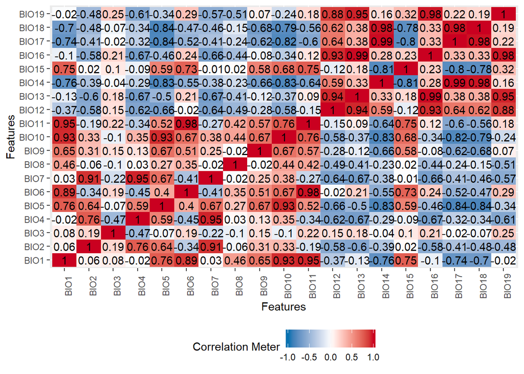

```r
plot_correlation(marcoclim) #para visualizar mejor la correlación.
```

Ahora, podemos representar los datos obtenidos, dependiendo de las variables que nos interesa mostrar:

Para generar un gráfico con temperatura y precipitación

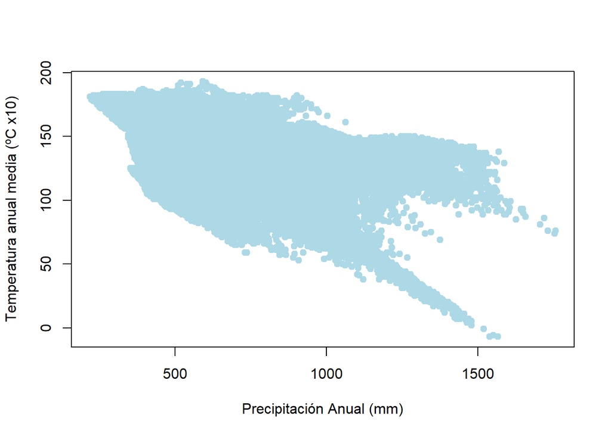

Temperatura y Precipitación en la Península Ibérica

[figure not shown]

Gráfico

```r
plot(marcoclim$BIO1~marcoclim$BIO12, pch=19, col="lightblue", xlab="Precipitación Anual (mm)", ylab="Temperatura anual media (ºC x10)") #ploteamos temperatura media anual y precipitacion anual)
```

Para generar un gráfico de densidad:

```r
str(marcoclim)
```

```
## Classes 'tbl_df', 'tbl' and 'data.frame':    41573 obs. of  19 variables:
##  $ BIO1 : int  134 132 132 131 131 130 129 128 128 128 ...
##  $ BIO2 : int  87 88 89 90 91 93 94 95 96 97 ...
##  $ BIO3 : int  40 40 40 41 40 41 41 41 41 41 ...
##  $ BIO4 : int  4612 4635 4680 4725 4785 4821 4839 4900 4937 4968 ...
##  $ BIO5 : int  247 247 248 248 249 250 251 251 252 253 ...
##  $ BIO6 : int  34 32 30 29 27 25 24 22 21 20 ...
##  $ BIO7 : int  213 215 218 219 222 225 227 229 231 233 ...
##  $ BIO8 : int  84 81 81 80 78 77 76 74 73 73 ...
##  $ BIO9 : int  175 173 174 173 173 173 173 173 190 191 ...
##  $ BIO10: int  193 191 192 192 192 192 191 191 191 191 ...
##  $ BIO11: int  75 73 72 70 69 68 67 65 64 64 ...
##  $ BIO12: int  1274 1276 1260 1249 1235 1226 1212 1201 1187 1171 ...
##  $ BIO13: int  155 155 153 151 150 148 146 145 143 140 ...
##  $ BIO14: int  64 64 63 63 62 62 61 61 60 60 ...
##  $ BIO15: int  23 23 23 23 23 22 22 22 22 21 ...
##  $ BIO16: int  418 418 413 408 403 399 394 390 384 377 ...
##  $ BIO17: int  236 238 235 235 232 232 229 229 226 225 ...
##  $ BIO18: int  271 270 267 266 263 261 258 256 253 225 ...
##  $ BIO19: int  390 390 385 381 377 373 369 366 361 354 ...
```

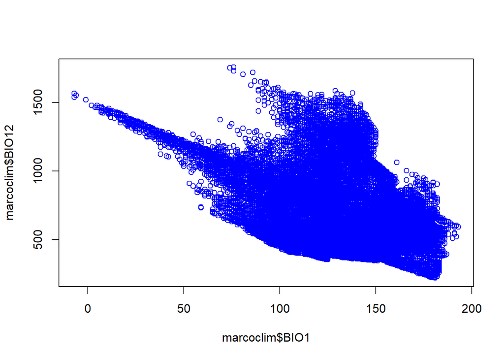

```r
plot(marcoclim$BIO12 ~ marcoclim$BIO1, col = "blue")
```

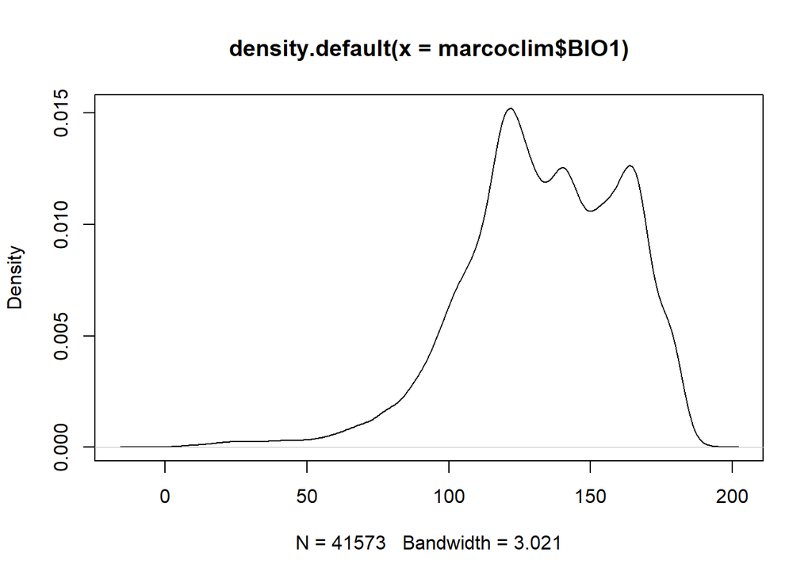

```r
d <- density(marcoclim$BIO1) # returns the density data
plot(d)
```

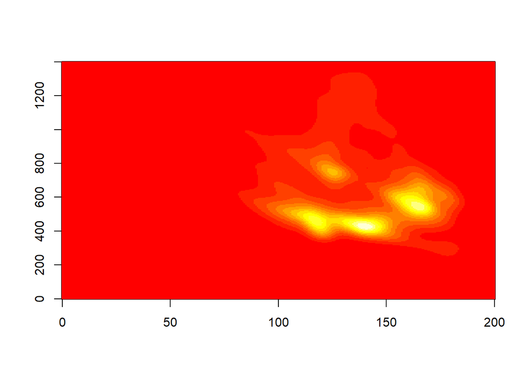

Grafico de densidad de Temperatura y Precipitación en la Península Ibérica

```r
dens <- kde2d(marcoclim$BIO1, marcoclim$BIO12, n=300, lims = c(0,200,0,1400))
image(dens)
```

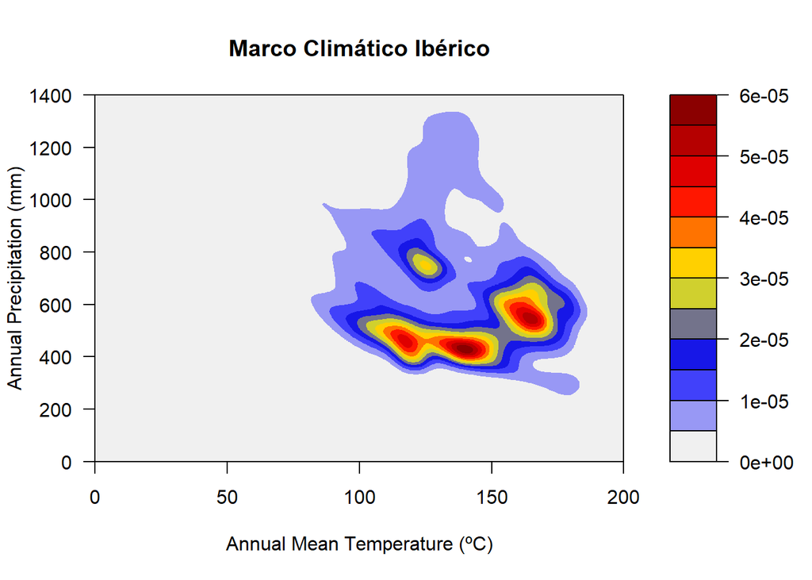

Grafico de densidad de Temperatura y Precipitación en la Península Ibérica

[figure not shown]

Gráfico

```r
filled.contour(dens,
               color.palette=colorRampPalette(c('gray94','blue','yellow','red','darkred')),
               xlab= "Annual Mean Temperature (ºC)",
               ylab= "Annual Precipitation (mm)", main = "Marco Climático Ibérico")
```

# 6 DESCARTAR VARIABLES MUY CORRELACIONADAS (opcional)

Al trabajar con 19 variables, algunas producto lineal de otras, estamos trabajando con información redundante. Podemos basarnos en el criterio VIF (factores de inflación de varianza), un enfoque simple para identificar la colinealidad entre las variables explicativas para descartar algunas y probar el modelo mas adelante con todas las variables y con solo las seleccionadas.

Esto se describe en : https://www.r-bloggers.com/collinearity-and-stepwise-vif-selection/

Definimos la función de cálculo y selección de variables con el VIF

```r
vif_func<-function(in_frame,thresh=10,trace=T,...){

  library(fmsb)

  if(any(!'data.frame' %in% class(in_frame))) in_frame<-data.frame(in_frame)

  #get initial vif value for all comparisons of variables
  vif_init<-NULL
  var_names <- names(in_frame)
  for(val in var_names){
    regressors <- var_names[-which(var_names == val)]
    form <- paste(regressors, collapse = '+')
    form_in <- formula(paste(val, '~', form))
    vif_init<-rbind(vif_init, c(val, VIF(lm(form_in, data = in_frame, ...))))
  }
  vif_max<-max(as.numeric(vif_init[,2]), na.rm = TRUE)

  if(vif_max < thresh){
    if(trace==T){ #print output of each iteration
      prmatrix(vif_init,collab=c('var','vif'),rowlab=rep('',nrow(vif_init)),quote=F)
      cat('\n')
      cat(paste('All variables have VIF < ', thresh,', max VIF ',round(vif_max,2), sep=''),'\n\n')
    }
    return(var_names)
  }
  else{

    in_dat<-in_frame

    #backwards selection of explanatory variables, stops when all VIF values are below 'thresh'
    while(vif_max >= thresh){

      vif_vals<-NULL
      var_names <- names(in_dat)

      for(val in var_names){
        regressors <- var_names[-which(var_names == val)]
        form <- paste(regressors, collapse = '+')
        form_in <- formula(paste(val, '~', form))
        vif_add<-VIF(lm(form_in, data = in_dat, ...))
        vif_vals<-rbind(vif_vals,c(val,vif_add))
      }
      max_row<-which(vif_vals[,2] == max(as.numeric(vif_vals[,2]), na.rm = TRUE))[1]

      vif_max<-as.numeric(vif_vals[max_row,2])

      if(vif_max<thresh) break

      if(trace==T){ #print output of each iteration
        prmatrix(vif_vals,collab=c('var','vif'),rowlab=rep('',nrow(vif_vals)),quote=F)
        cat('\n')
        cat('removed: ',vif_vals[max_row,1],vif_max,'\n\n')
        flush.console()
      }

      in_dat<-in_dat[,!names(in_dat) %in% vif_vals[max_row,1]]

    }

    return(names(in_dat))

  }

}
```

Aplicamos la función a los datos

```r
vif_func(in_frame=marcoclim,thresh=5,trace=T) # La funcion va calculando los VIF cada vez que quita el que tiene mayor valor hasta quedarnos con valores de VIF por debajo del umbral (hemos puesto 5, pero podria ser otro)
```

```
##  var   vif
##  BIO1  840.219409011441
##  BIO2  232.361286240665
##  BIO3  35.5651834933497
##  BIO4  1007.6438795429
##  BIO5  Inf
##  BIO6  Inf
##  BIO7  Inf
##  BIO8  3.94266447332863
##  BIO9  4.33236420250074
##  BIO10 3153.22471219834
##  BIO11 1657.00763320092
##  BIO12 243.762214521014
##  BIO13 100.764699948118
##  BIO14 110.390664221877
##  BIO15 24.5936416782556
##  BIO16 330.10411376451
##  BIO17 174.706262131492
##  BIO18 119.006405973729
##  BIO19 175.931813287998
##
## removed:  BIO5 Inf
##
##  var   vif
##  BIO1  840.219409011441
##  BIO2  232.361286240665
##  BIO3  35.5651834933491
##  BIO4  1007.6438795429
##  BIO6  170.334548496541
##  BIO7  438.175185602013
##  BIO8  3.94266447332864
##  BIO9  4.33236420250074
##  BIO10 3153.22471219834
##  BIO11 1657.00763320092
##  BIO12 243.762214521014
##  BIO13 100.764699948118
##  BIO14 110.390664221877
##  BIO15 24.5936416782554
##  BIO16 330.10411376451
##  BIO17 174.706262131492
```

[output cut: 165 more lines]

```
##  BIO14 10.5717136563812
##  BIO15 10.4104872193402
##
## removed:  BIO14 10.57171
##
##  var   vif
##  BIO1  6.33322997017621
##  BIO2  2.50561257534862
##  BIO3  1.25595469175483
##  BIO8  2.68241601020737
##  BIO9  2.56330386967442
##  BIO13 2.98530656016564
##  BIO15 3.63301707310088
##
## removed:  BIO1 6.33323
```

```
## [1] "BIO2"  "BIO3"  "BIO8"  "BIO9"  "BIO13" "BIO15"
```

# 7 Reducción de dimensionalidad mediante PCA

PAra describir de forma reducida el marco climático Ibérico realizamos una reducción de dimensiones por Analisis de Componentes principales:

Cargamos los datos

```r
marcoclim<- read_csv("Datos/MarcoClim2.5.csv",
    col_types = cols(X1 = col_skip()))
#View(marcoclim)
marcoclim <- marcoclim[complete.cases(marcoclim),] # Elimina NA
```

PCA con todos los datos:

```r
pcaclim <- prcomp(marcoclim, center = TRUE, scale. = TRUE)
print(pcaclim)
```

```
## Standard deviations (1, .., p=19):
##  [1] 2.965413e+00 2.352836e+00 1.434030e+00 1.083214e+00 7.979601e-01
##  [6] 6.759996e-01 4.691096e-01 2.387853e-01 1.588771e-01 1.253230e-01
## [11] 1.000660e-01 7.725408e-02 6.921490e-02 5.674219e-02 4.655173e-02
## [16] 4.082176e-02 3.073569e-02 1.343087e-02 7.710935e-15
##
## Rotation (n x k) = (19 x 19):
##               PC1          PC2         PC3          PC4         PC5
## BIO1  -0.26298313  0.231183922 -0.14582593  0.032011992  0.24153091
## BIO2  -0.18739619 -0.237139854  0.32758444 -0.290207254  0.21126824
## BIO3   0.01532037  0.132269467  0.11223334 -0.855335968  0.04709838
## BIO4  -0.16973374 -0.309602263  0.19745924  0.289236172  0.18002426
## BIO5  -0.32087060 -0.001894929  0.11885418  0.065986865  0.26263007
## BIO6  -0.15421609  0.351164623 -0.20335209  0.002383268  0.09654595
## BIO7  -0.19534332 -0.286889916  0.28375338  0.063976767  0.18397353
## BIO8  -0.13374007 -0.013328198 -0.56005231 -0.028651752  0.16302528
## BIO9  -0.22267732  0.145441919  0.20841614 -0.076082206  0.34550940
## BIO10 -0.31070498  0.104407069 -0.05759577  0.142215760  0.27137728
## BIO11 -0.19476181  0.318608201 -0.19547904 -0.049132385  0.14340212
## BIO12  0.26797414  0.209924809  0.18369305  0.096345542  0.22242622
## BIO13  0.20318929  0.298807491  0.19087700  0.131463268  0.08671118
## BIO14  0.30645350 -0.108055344 -0.10363658 -0.013922292  0.31643725
## BIO15 -0.20622134  0.282890964  0.16999023  0.117296868 -0.30487512
## BIO16  0.19128114  0.310097628  0.22271609  0.114912682  0.06059261
## BIO17  0.30964509 -0.085571289 -0.09145850 -0.012772311  0.37213420
## BIO18  0.30710575 -0.075700685 -0.16059407  0.029845508  0.33278648
## BIO19  0.15335538  0.321449396  0.30272963  0.083784477  0.08438043
##               PC6          PC7         PC8         PC9         PC10
## BIO1  -0.04402426 -0.218777119 -0.07751051 -0.08092533  0.157803386
## BIO2  -0.24930329  0.004996878  0.08389167 -0.02986251 -0.338308279
## BIO3  -0.16474111 -0.053906539  0.01132554 -0.04865309  0.346085552
## BIO4  -0.14933899  0.001366079 -0.02285174 -0.05086946  0.627612415
## BIO5  -0.12769349 -0.156462257 -0.05751115  0.15126248 -0.324825355
## BIO6   0.06783852 -0.224725909 -0.11778447  0.15911440 -0.123042073
## BIO7  -0.18260282  0.026100093  0.03814617  0.02195491 -0.224593643
## BIO8  -0.43683019  0.640621300  0.10170775  0.16745024  0.002917985
## BIO9   0.68938564  0.505553210  0.14465076 -0.05116709  0.028172956
## BIO10 -0.08377133 -0.190454203 -0.03073347 -0.12007308  0.290711421
## BIO11  0.01538836 -0.189784836  0.01149555 -0.12499355 -0.161837673
## BIO12 -0.13582902  0.039752602 -0.06236625  0.15574627 -0.119554942
```

[output cut: 32 more lines]

```
## BIO5   0.2650675655  0.0603202065 -0.0236654585 -6.128538e-01
## BIO6  -0.2377531476  0.0152728992 -0.0027020098  4.979508e-01
## BIO7   0.4577177196  0.0478556966 -0.0214453514  6.135595e-01
## BIO8   0.0040278678 -0.0008390805 -0.0001106441 -1.496518e-16
## BIO9  -0.0202552064  0.0171067966 -0.0043664326 -1.634907e-16
## BIO10 -0.0400456264 -0.2504471612  0.7445030848  1.267556e-15
## BIO11  0.0421357593 -0.6003331864 -0.4737767237 -2.004199e-15
## BIO12 -0.2584610674  0.1191791501  0.0291595243  5.841562e-16
## BIO13  0.1229605910 -0.0034920017  0.0010482321 -1.816408e-16
## BIO14 -0.1939577121 -0.0419618399 -0.0138025852  2.563236e-16
## BIO15  0.0586764745  0.0575877212  0.0023764821  1.303913e-16
## BIO16 -0.2519645237  0.0356645188 -0.0033680779  3.289464e-16
## BIO17  0.1705254262  0.0318094179  0.0170709959  9.520220e-17
## BIO18  0.2084469654 -0.0221507307 -0.0121060018 -5.717575e-16
## BIO19  0.2968483272 -0.1625464564 -0.0209929209 -5.310582e-16
```

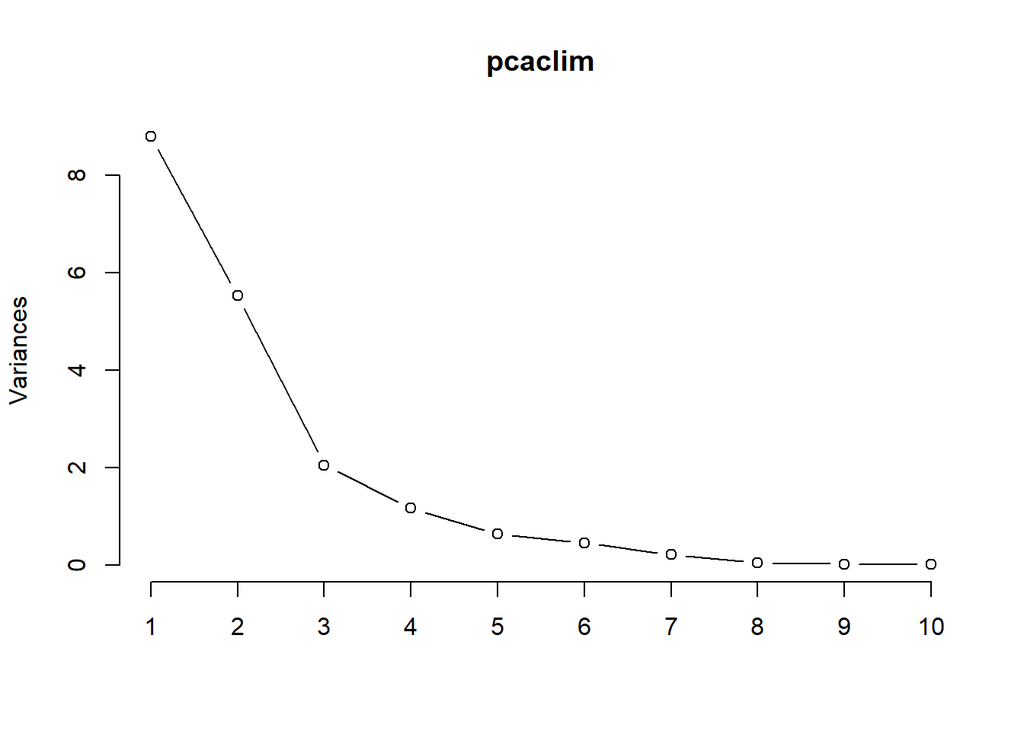

```r
plot(pcaclim, type = "l")
```

```r
summary(pcaclim)
```

```
## Importance of components:
##                           PC1    PC2    PC3     PC4     PC5     PC6
## Standard deviation     2.9654 2.3528 1.4340 1.08321 0.79796 0.67600
## Proportion of Variance 0.4628 0.2914 0.1082 0.06176 0.03351 0.02405
## Cumulative Proportion  0.4628 0.7542 0.8624 0.92417 0.95769 0.98174
##                            PC7    PC8     PC9    PC10    PC11    PC12
## Standard deviation     0.46911 0.2388 0.15888 0.12532 0.10007 0.07725
## Proportion of Variance 0.01158 0.0030 0.00133 0.00083 0.00053 0.00031
## Cumulative Proportion  0.99332 0.9963 0.99765 0.99848 0.99900 0.99932
##                           PC13    PC14    PC15    PC16    PC17    PC18
## Standard deviation     0.06921 0.05674 0.04655 0.04082 0.03074 0.01343
## Proportion of Variance 0.00025 0.00017 0.00011 0.00009 0.00005 0.00001
## Cumulative Proportion  0.99957 0.99974 0.99985 0.99994 0.99999 1.00000
##                             PC19
## Standard deviation     7.711e-15
## Proportion of Variance 0.000e+00
## Cumulative Proportion  1.000e+00
```

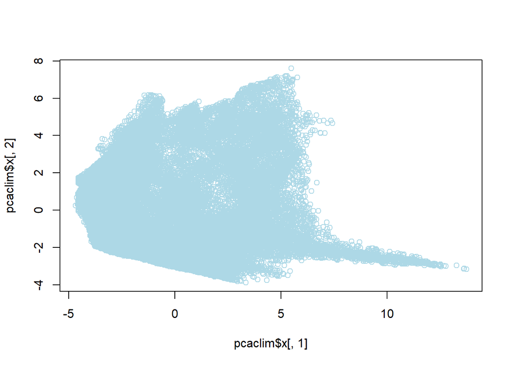

[figure not shown]

```r
plot(pcaclim$x[,1],pcaclim$x[,2], col = "lightblue")
```

Se explica un 75,42% de la variabilidad con el componente principal 1 y 2. Nos parece suficiente para continuar.

PCA solo con las variables que VIF < 5

```r
marcoclimVIF <- marcoclim[,c(2,3,8,9,13,15)]

pcaclim2 <- prcomp(marcoclimVIF, center = TRUE, scale. = TRUE)
print(pcaclim2)
```

```
## Standard deviations (1, .., p=6):
## [1] 1.3524365 1.2860802 1.0654207 0.9254183 0.5891390 0.4222654
##
## Rotation (n x k) = (6 x 6):
##              PC1        PC2           PC3         PC4         PC5
## BIO2   0.5847990 -0.1537217  0.4433505181 -0.16127525 -0.31327559
## BIO3   0.1423285  0.3323668  0.5005925403  0.75386437  0.02402120
## BIO8   0.1799236 -0.3624470 -0.5773202665  0.61377365  0.01532740
## BIO9   0.5217284  0.4010906 -0.1895958425 -0.15176273  0.70940357
## BIO13 -0.4945363  0.5305331  0.0003560409  0.06181622  0.01085418
## BIO15  0.2976802  0.5405507 -0.4284880702 -0.04590784 -0.63061495
##               PC6
## BIO2  -0.56006138
## BIO3   0.22314454
## BIO8  -0.35497599
## BIO9  -0.06851167
## BIO13 -0.68558685
## BIO15  0.18922640
```

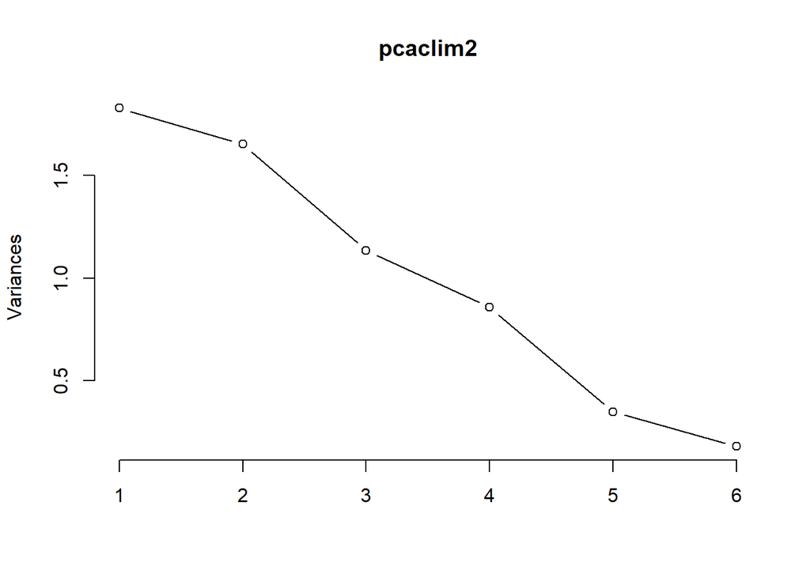

```r
plot(pcaclim2, type = "l")
```

```r
summary(pcaclim2)
```

```
## Importance of components:
##                           PC1    PC2    PC3    PC4     PC5     PC6
## Standard deviation     1.3524 1.2861 1.0654 0.9254 0.58914 0.42227
## Proportion of Variance 0.3049 0.2757 0.1892 0.1427 0.05785 0.02972
## Cumulative Proportion  0.3049 0.5805 0.7697 0.9124 0.97028 1.00000
```

Otro plot interesante, es por ejemplo, la contribución de cada una de las variables en el análisis de componentes principales.

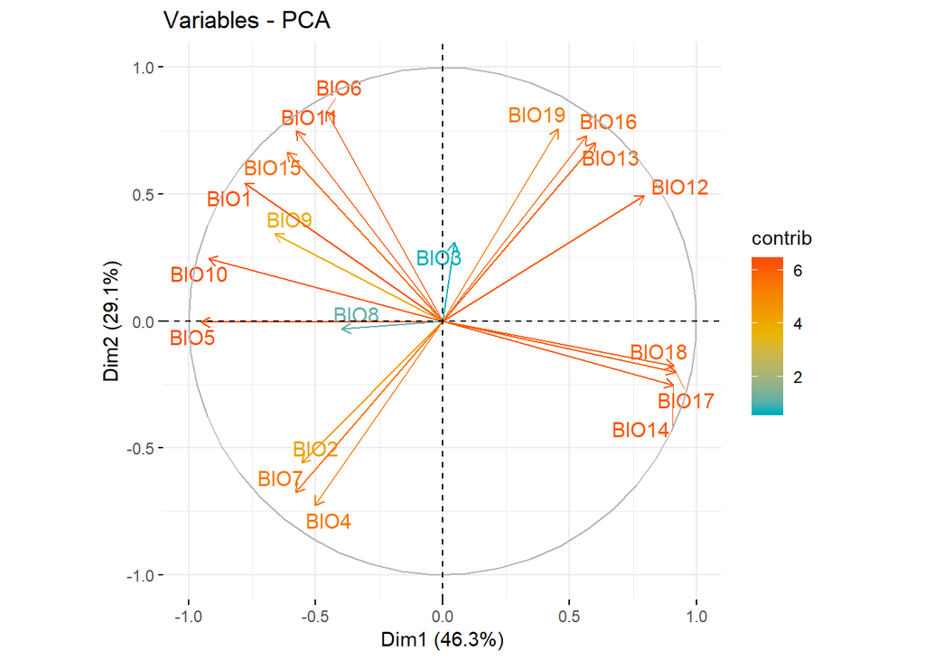

```r
fviz_pca_var(pcaclim,
             col.var = "contrib", # Color by contributions to the PC
             gradient.cols = c("#00AFBB", "#E7B800", "#FC4E07"),
             repel = TRUE     # Avoid text overlapping
)  ##Función para ver la contribución de cada variable en esta PCA
```

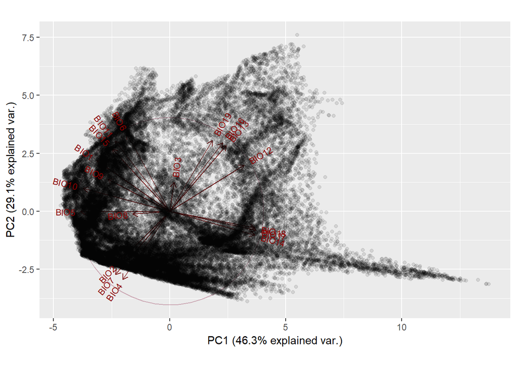

[figure not shown]

```r
## Manera de representar la PCA extraído de https://tgmstat.wordpress.com/2013/11/28/computing-and-visualizing-pca-in-r/

g <- ggbiplot(pcaclim, obs.scale = 1, var.scale = 1,
               ellipse = TRUE, alpha=0.1,
              circle = TRUE)
g <- g + scale_color_discrete(name = '')
g <- g + theme(legend.direction = 'horizontal',
               legend.position = 'top')
print(g)
```

# 8 Obtención de datos de países y proyección sobre el MCI

Pretendemos evaluar país por país, si sus condiciones climáticas se parecen a las de la península ibérica, con el fin de determinar después especies que podrían encontrar condiciones favorables en nuestro país actuando como invasoras. Por eso proyectamos los datos de marco climático de estos países sobre el nuestro.

Cargamos los datos del marco climatico ibérico:

```r
marcoclim<- read_csv("Datos/MarcoClim2.5.csv",
    col_types = cols(X1 = col_skip()))
#View(marcoclim)
marcoclim <- marcoclim[complete.cases(marcoclim),] # Elimina NA
```

Preparamos los datos de la Península Ibérica de los dos primeros componentes:

```r
e <- pcaclim$x[,1:2]
edf <- as.data.frame(e)
edf$pais <- "Spain" #Añadimos una varaible de Pais, con todas las etiquetes "Spain"
head(edf)
```

```
##        PC1      PC2  pais
## 1 5.484546 2.562478 Spain
## 2 5.546462 2.450768 Spain
## 3 5.409187 2.319664 Spain
## 4 5.379469 2.235768 Spain
## 5 5.264471 2.053843 Spain
## 6 5.212054 1.931282 Spain
```

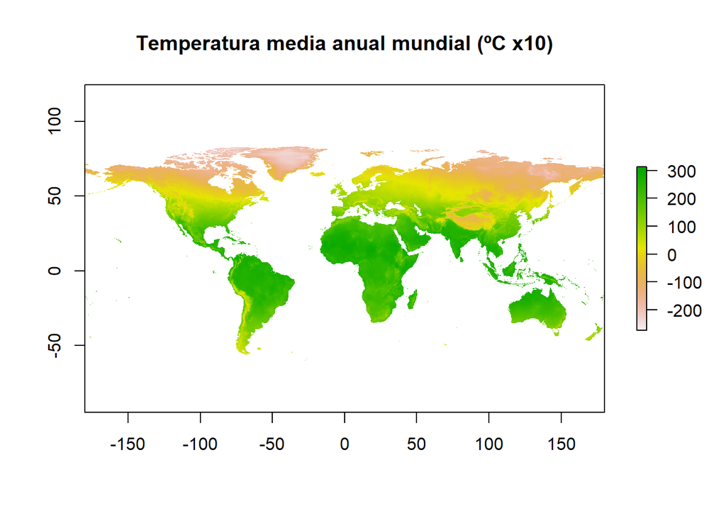

```r
#Download the WorldClim Data
worldata <- getData("worldclim",var="bio", res=2.5)
plot(worldata$bio1, main =  "Temperatura media anual mundial (ºC x10)")
```

En: https://www.gis-blog.com/r-raster-data-acquisition, encontramos como se realiza la descarga y recorte de los paises. Para llamar a un pais concreto se usa la nomenclatura de tres letras definida en: http://kirste.userpage.fu-berlin.de/diverse/doc/ISO_3166.html. Hay una base de datos con los nombres y codigos de los 241 paises que incluye la lista. Podemos importar esos datos:

```r
CountryCodes <- read_delim("Datos/CountryCodes.csv",
    ";", escape_double = FALSE, trim_ws = TRUE)
#A3 son los codigos para descargar el pais
```

Descargamos los límites políticos de un país con la función:

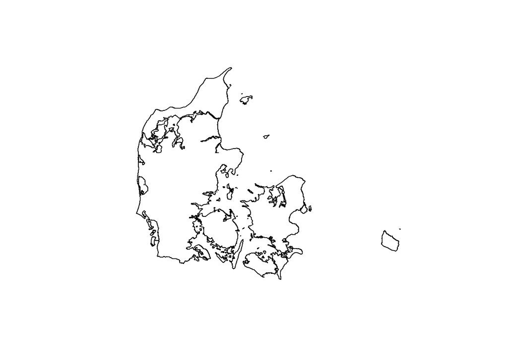

```r
denmark <- getData('GADM', country='DNK', level=0)
plot(denmark)
```

```r
s<- crop(worldata, denmark)
s2 <- mask(s, denmark)
s2<-as.matrix(s2)
marcoclim.denmark <- as.data.frame(s2)
names(marcoclim.denmark) <- c("BIO1","BIO2","BIO3","BIO4", "BIO5", "BIO6", "BIO7", "BIO8", "BIO9",
                 "BIO10","BIO11","BIO12","BIO13", "BIO14", "BIO15", "BIO16", "BIO17", "BIO18", "BIO19")

marcoclim.denmark <- marcoclim.denmark[complete.cases(marcoclim.denmark),]
```

[figure not shown]

Proyectamos estos valores sobre el PCA del marco climático ibérico. Generamos la variable país, con el nombre de la etiqueta del mismo. Además combinamos los dos data frames, con los datos de PC1 y PC2 de España y el país seleccionado.

```r
i <- predict (pcaclim, newdata = marcoclim.denmark)
i <- i[,1:2]

idf <- as.data.frame(i)
idf$pais <- "Din"

df <- rbind(edf,idf)
```

Generamos un gráfico para visualizar el grado de solapamiento de ambas nubes de puntos:

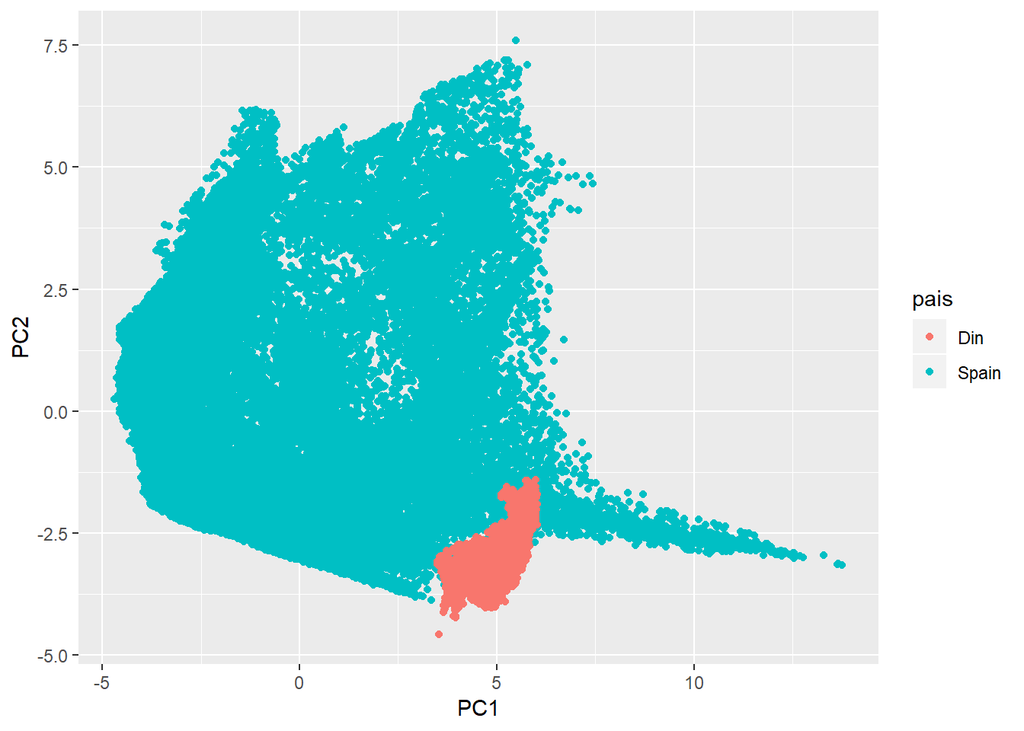

[figure not shown]

```r
ggplot(df, aes(x=PC1, y=PC2, col=pais)) + geom_point()
```

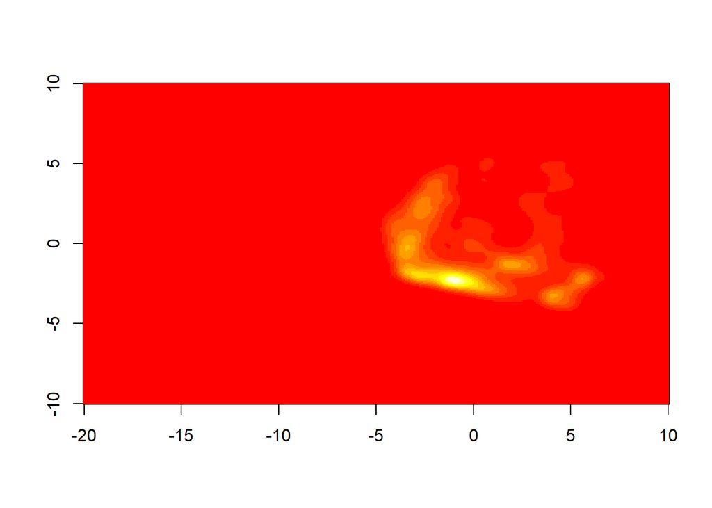

```r
# PARA HACER UN SOLO GRAFICO DE DENSIDAD CON TODOS LOS DATOS SERIA ASí
dens <- kde2d(df$PC1, df$PC2, n=300, lims = c(-20,10,-10,10))
image(dens)
```

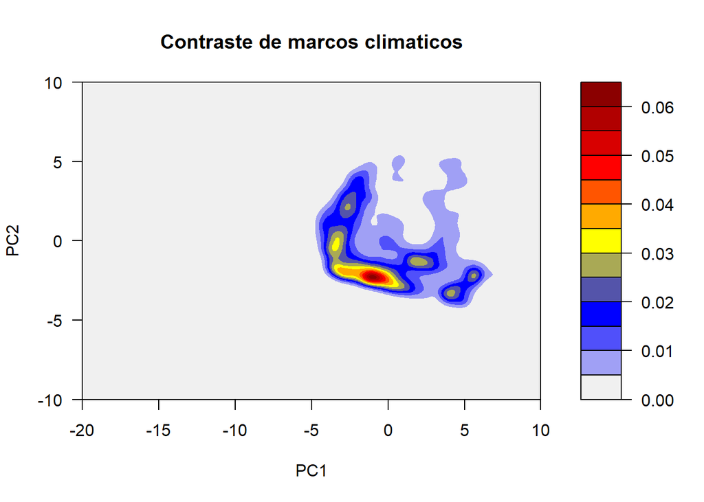

```r
filled.contour(dens,
               color.palette=colorRampPalette(c('gray94','blue','yellow','red','darkred')),
               xlab= "PC1",
               ylab= "PC2", main = "Contraste de marcos climaticos")
```

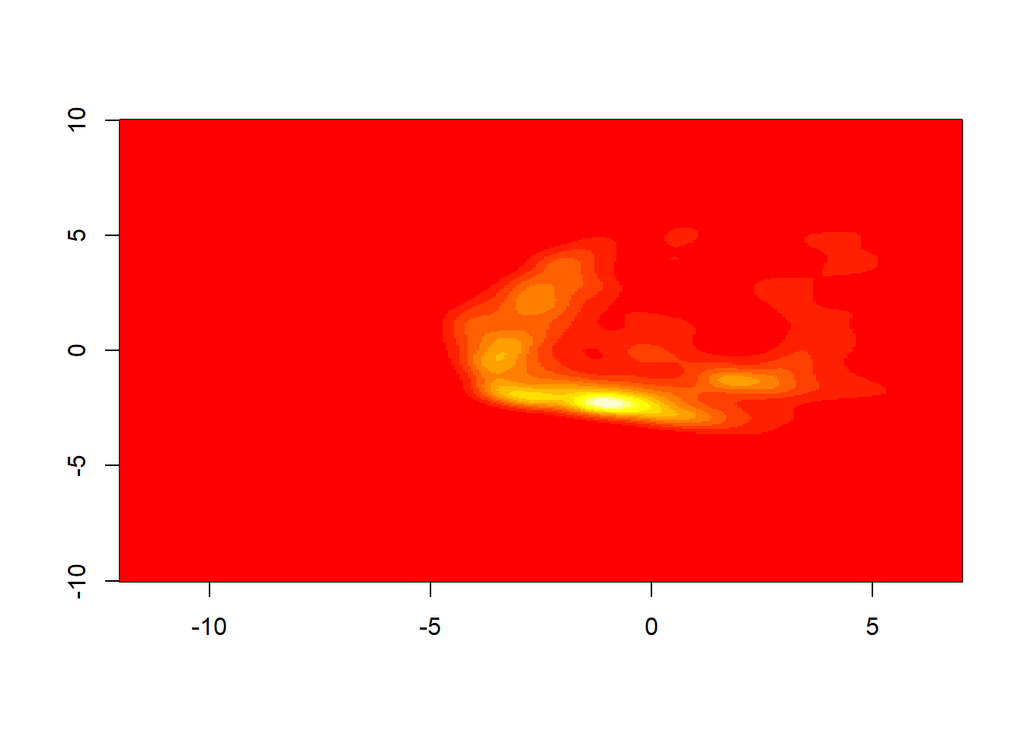

```r
# AHORA SOLO ESPAÑA:
dense <- kde2d(edf$PC1, edf$PC2, n=300, lims = c(-12,7,-10,10))
image(dense)
```

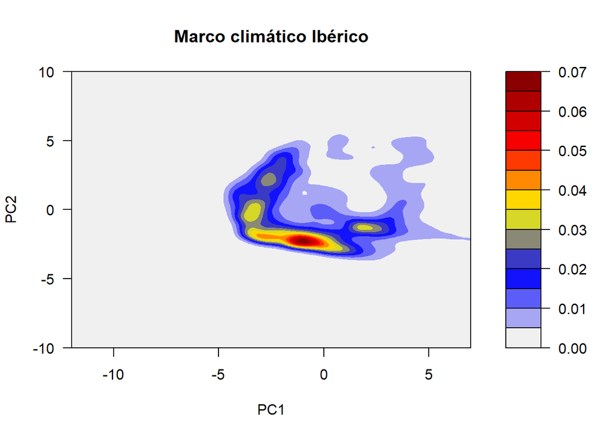

```r
filled.contour(dense,
               color.palette=colorRampPalette(c('gray94','blue','yellow','red','darkred')),
               xlab= "PC1",
               ylab= "PC2", main = "Marco climático Ibérico")
```

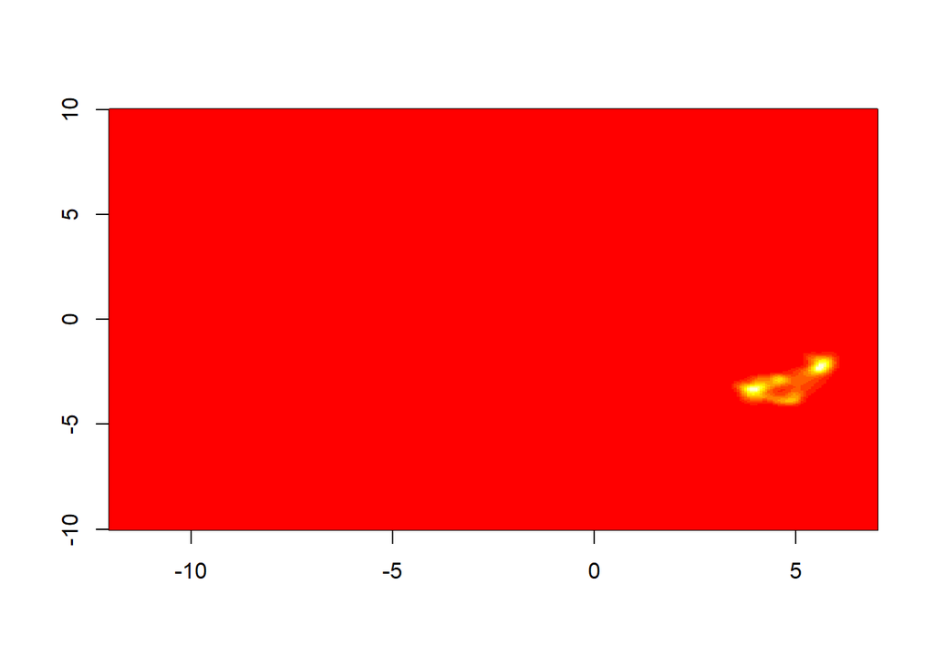

```r
#AHORA SOLO EL PAIS PROYECTADO:
densi <- kde2d(idf$PC1, idf$PC2, n=300, lims = c(-12,7,-10,10))
image(densi)
```

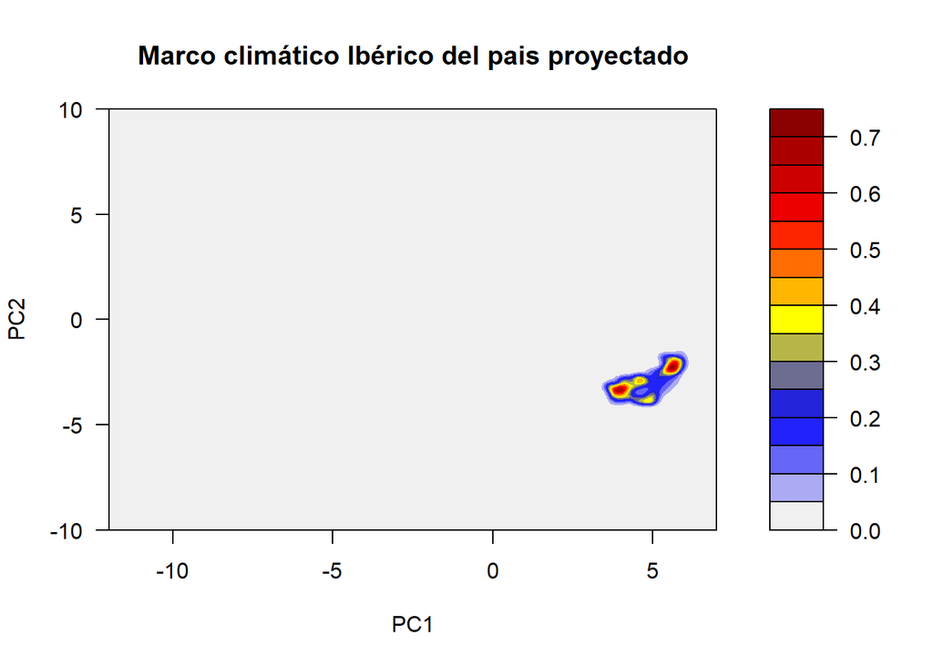

```r
filled.contour(densi,
               color.palette=colorRampPalette(c('gray94','blue','yellow','red','darkred')),
               xlab= "PC1",
               ylab= "PC2", main = "Marco climático Ibérico del pais proyectado")
```

```r
#Como se ponen los dos juntos??
```

[figure not shown]

[figure not shown]

# 9 Determinación del riesgo invasor

Queremos cuantificar el grado de solapamiento de las nubes de puntos descritas por los puntos de los dos países, el receptor (España) y el proyectado. Hay que crear ciertos metricos para la determinación de el grado de riesgo de invasión.

# 10 Significación por *bootstraping*

Realizar una ANOVA con permutaciones por Bootstraping: contraste de la distribución de etiquetas a l’azar con la distribuci?n real de etiquetas. ?La assignaci?n podria haber sido al azar? Si el resultado resulta significativo, hay diferenciaci?n del espacio climatico y por lo tanto las especies del pais proyectado no podrian sobrevivir en Espa?a.

# 11 Significación por Test de Permutación

# 12 Grado de solapamiento desde el receptor y desde el proyectado

# 13 Otros?

# 14 OBTENCION DATOS DE ESPECIES INVASORAS MUNDIALES. ORIGEN Y PRESENCIA

Turbelin et al. 2017, utilizan datos de http://www.iucngisd.org/gisd/ y de https://www.cabi.org/isc/. para determinar los patrones de distribucion de especies invasoras, en CABI existen datasets de cada una de las especies ex?ticas invasoras. Descargamos estos datos para una lista de plantas, recogen pa?s donde la planta est? presente, latitud longitud, si es nativa o introducida, etc. Los uniremos entre si? .

# 15 Bibliograf?a

# 16 Sitios web

https://worldclim.org/bioclim https://www.cabi.org/isc/. https://www.r-bloggers.com/collinearity-and-stepwise-vif-selection/ https://tgmstat.wordpress.com/2013/11/28/computing-and-visualizing-pca-in-r/ https://www.gis-blog.com/r-raster-data-acquisition http://kirste.userpage.fu-berlin.de/diverse/doc/ISO_3166.html. https://stackoverflow.com/questions/31272695/calculate-probability-of-point-on-2d-density-surface https://rstudio-pubs-static.s3.amazonaws.com/330387_5a40ca72c3b14824acedceb7d34618d1.html

https://stats.stackexchange.com/questions/63447/integrating-kernel-density-estimator-in-2d

# 17 Artículos y libros

Turbelin, Anna J., Malamud, Bruce D., Francis, Robert A.Mapping the global state of invasive alien species: patterns of invasion and policy responses.*Global Ecology & Biogeography*, September 2016.

Davison, A. C. & Hinkley, D. V. (1997) Bootstrap Methods and Their Applications. Cambridge University Press, Cambridge. ISBN 0-521-57391-2